# Homework 11

Lindsey Pett

4/4/2018

1. Use the code from class as a template and analyze a function of your choosing that is relevant to your own research. Do not change any of the functions in the class code. Instead, copy and rename functions for your own project. Edit those copies, and then modify the lines of code in the main body of your program to call the new functions. If you do this carefully, you will be able to take full advantage of the existing program, but adapt it for your specific use.

```r
# exponential growth N(t)=N(0)e^(r)(t)

##################################################
# function: exponentail growth
# input: N(0)= inital population
#       e^rt; e is a constant = 2.71, r = intrinsic rate of increase, t = time
# output: N and time t
#-------------------------------------------------
ExponentialCurve<-function(N0=20,r=0.5,t=1:10){

  Nt<- N0*exp(r*t)
return(Nt)
}
head(ExponentialCurve())
```

```
## [1]  32.97443  54.36564  89.63378 147.78112 243.64988 401.71074
```

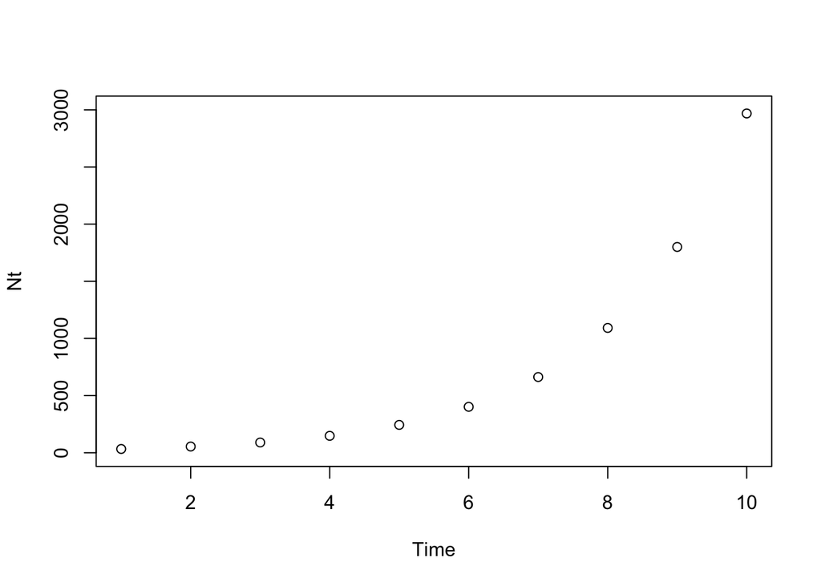

```r
# function: ExponentialPlot
# plot exponential growth curve
# input: N(0)= inital population
#       e^rt; e is a constant = 2.71, r = intrinsic rate of increase, t = time
# output:graphical representation of exponential plot
#-------------------------------------------------
ExponentialPlot <- function(N0=20,r=0.5,t=1:10) {
plot(x=t,y= N0*exp(r*t),type="p",xlab="Time",ylab="Nt",ylim=c(0,3000))
#mtext(paste("t =", t,"  e =",e),cex=0.7)
      return()
}
ExponentialPlot()
```

2. Similarly, use the code from yesterday’s class to design and conduct a randomization test for some of your own data. You will need to modify the functions that read in the data, calculate the metric, and randomize the data. Once those are set up, the program should run correctly calling your new functions. Also, to make your analysis fully repeatable, make sure you set the random number seed at the beginning (use either set.seed() in base R, or char2seed in the TeachingDemos package

```r
myData<-read.csv(file="hw11.csv")
#preliminaries
library(ggplot2)
library(TeachingDemos)
char2seed("May Flowerx")

########################################################
# FUNCTION: readData
# read in or generate data frame
# input: file name (or nothing for demo)
# output: 3-column data frame of observed data (ID, xj, y)
#-------------------------------------------------------
readData <- function(z=NULL) {
             if(is.null(z)) {
               xVar <- myData$xVar
               yVar <- myData$yVar
               dF <- data.frame(ID=seq_along(xVar),xVar,yVar) }

               return(dF)
}
readData()
```

```
##    ID xVar        yVar
## 1   1    1 424.2195122
## 2   2    2 192.4146341
## 3   3    3 458.7560976
## 4   4    4   0.0000000
## 5   5    5 184.8048780
## 6   6    6 247.9268293
## 7   7    7   0.0000000
## 8   8    8 329.6829268
## 9   9    9 365.7317073
## 10 10   10   1.1951220
## 11 11   11 317.7560976
## 12 12   12 543.0487805
## 13 13   13 247.5121951
## 14 14   14 677.6829268
```

[output cut: 26 more lines]

```r
########################################################
# FUNCTION: getMetric
# calculate metric for randomization test
# input: 3-column data frame for regression
# output: regression slope
#-------------------------------------------------------
getMetric <- function(z=NULL) {
              if(is.null(z)) {
                xVar <- myData$xVar
                yVar <- myData$yVar
                z <- data.frame(ID=seq_along(xVar),xVar,yVar) }

  . <- lm(z[,3]~z[,2])
  . <- summary(.)
  . <- .$coefficients[2,1]
  slope <- .
  return(slope)

}
getMetric()
```

```
## [1] -1.320574
```

```r
########################################################
# FUNCTION: shuffleData
# randomize data for regression analysis
# input: 3-column data frame (ID,xVar,yVar)
# output: 3-column data frame (ID,xVar,yVar)
#-------------------------------------------------------
shuffleData <- function(z=NULL) {
                 if(is.null(z)) {
                 xVar <- myData$xVar
                 yVar <- myData$yVar
                 z <- data.frame(ID=seq_along(xVar),xVar,yVar) }
z[,3] <- sample(z[,3])
return(z)
}
shuffleData()
```

```
##    ID xVar        yVar
## 1   1    1 321.5121951
## 2   2    2 219.3170732
## 3   3    3 247.5121951
## 4   4    4 365.7317073
## 5   5    5 430.6097561
## 6   6    6 329.6829268
## 7   7    7 543.0487805
## 8   8    8   6.6829268
## 9   9    9 458.7560976
## 10 10   10 381.0487805
## 11 11   11 312.9024390
## 12 12   12   0.0000000
## 13 13   13   1.0487805
## 14 14   14 176.2195122
```

[output cut: 26 more lines]

```r
########################################################
# FUNCTION: getPVal
# calculate p value for observed, simulated data
# input: -list of observed metric
#        -vector of simulated metric
# output: lower, upper tail probability vector
#-------------------------------------------------------
getPVal <- function(z=NULL) {
            if(is.null(z)){
              z <- list(xObs=runif(1), xSim=runif(1000)) }

  pLower <- mean(z[[2]] <=z[[1]])
  pUpper <- mean(z[[2]] >=z[[1]])

  return(c(pL=pLower,pU=pUpper))

}
getPVal()
```

```
##    pL    pU
## 0.245 0.755
```

```r
#----------------------------------------------
# main body of code
nSim <- 1000 # number of simulations
Xsim <- rep(NA,nSim) # will hold simulated slopes

dF <- readData()
Xobs <- getMetric(dF)

for (i in seq_len(nSim)) {
  Xsim[i] <- getMetric(shuffleData(dF))}

slopes <- list(Xobs,Xsim)
getPVal(slopes)
```

```
##    pL    pU
## 0.307 0.693
```

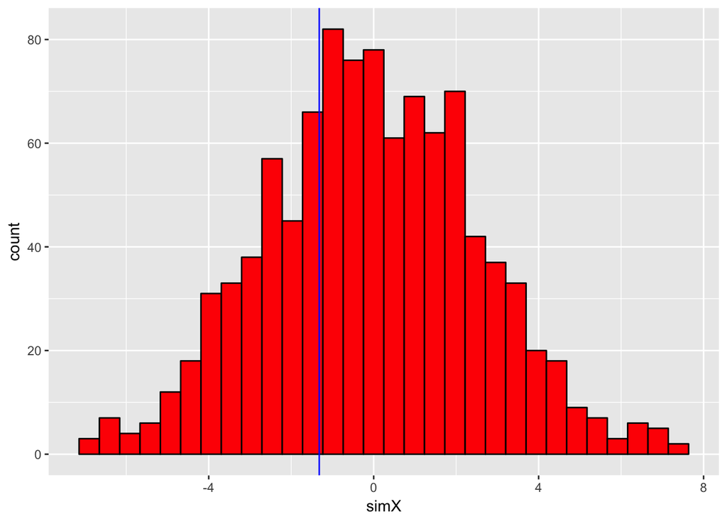

```r
########################################################
# FUNCTION: plotRanTest
# ggplot graph
# input: list of the observed metric and vector of simulated metric
# output: ggplot graph
#-------------------------------------------------------
plotRanTest <- function(z=NULL) {
                if(is.null(z)){
                z <- list(xObs=runif(1), xSim=runif(1000)) }

dF <- data.frame(ID=seq_along(z[[2]]),
                 simX=z[[2]])
p1 <- ggplot(data=dF,mapping=aes(x=simX))
p1 + geom_histogram(mapping=aes(fill=I("red"), color=I("black"))) + geom_vline(aes(xintercept=z[[1]],col="blue"))
}
plotRanTest(slopes)
```

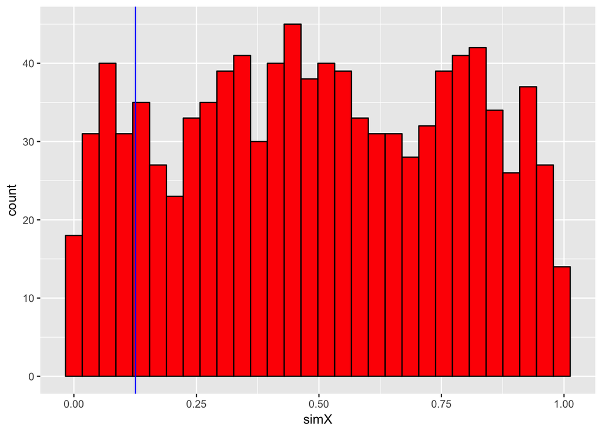

```r
plotRanTest()
```

3. For comparison, calculate in R the standard statistical analysis you would use with these data. How does the p-value compare for the standard test versus the p value you estimated from your randomization test? If the p values seem very different, run the program again with a different starting seed (and/or increase the number of replications in your randomization test). If there are persistent differences in the p value of the standard test versus your randomization, what do you think is responsible for this difference?

The pvalues seem to change in the shuffel data when the char2seed changes. This perhaps is due to the function of char2seed. char2seed function creates a seed for the random number generator from a character string. Different letters or amount of letters will create a different pvalues.

```r
anovaread<-aov(xVar~yVar,data=readData())
anovashuffle<-aov(xVar~yVar,data=shuffleData())
summary(anovaread)
```

```
##             Df Sum Sq Mean Sq F value Pr(>F)
## yVar         1     34   33.76   0.242  0.625
## Residuals   38   5296  139.37
```

```r
summary(anovashuffle)
```

```
##             Df Sum Sq Mean Sq F value Pr(>F)
## yVar         1    257   257.4   1.928  0.173
## Residuals   38   5073   133.5
```